# Plot Local Inverse Simpson Index (LISI)

Ramon Massoni-Badosa

2021/01/29

# 1 Introduction

In previous notebooks we have visualized to which extent [Harmony](https://www.nature.com/articles/s41592-019-0619-0) was able to correct for batch effects. However, UMAPs represent a 2D visual representation of the data, which is probabilistic, non-linear and largely overplotted. Thus, it is important to quantify the success of the batch effect correction using the latent space (PCA).

- It is extremely easy to use with a [stand-alone package](https://github.com/immunogenomics/LISI).
- It is implemented in C++ and scales well to hundreds of thousands of cells.
- The contribution of each neighbor is weighted.

LISI scores were computed in the previous notebook. Here, we will plot the results.

# 2 Pre-processing

## 2.1 Load packages

```r
library(ggridges)
library(tidyverse)
```

## 2.2 Parameters

```r
# Paths
path_to_lisi_scores <- here::here("scRNA-seq/2-QC/5-batch_effect_correction/3-data_integration_multiome/tmp/lisi_scores.rds")
path_tmp_dir <- here::here("scRNA-seq/2-QC/5-batch_effect_correction/3-data_integration_multiome/tmp/")
path_to_confounders_df <- str_c(path_tmp_dir, "confounders_df.rds", sep = "")
path_to_save_supp_df <- here::here("data/raw_data_figures/lisi_scores_rna.csv")
```

## 2.3 Load data

```r
lisi_scores <- readRDS(path_to_lisi_scores)
confounders_df <- readRDS(path_to_confounders_df)
```

# 3 Plot

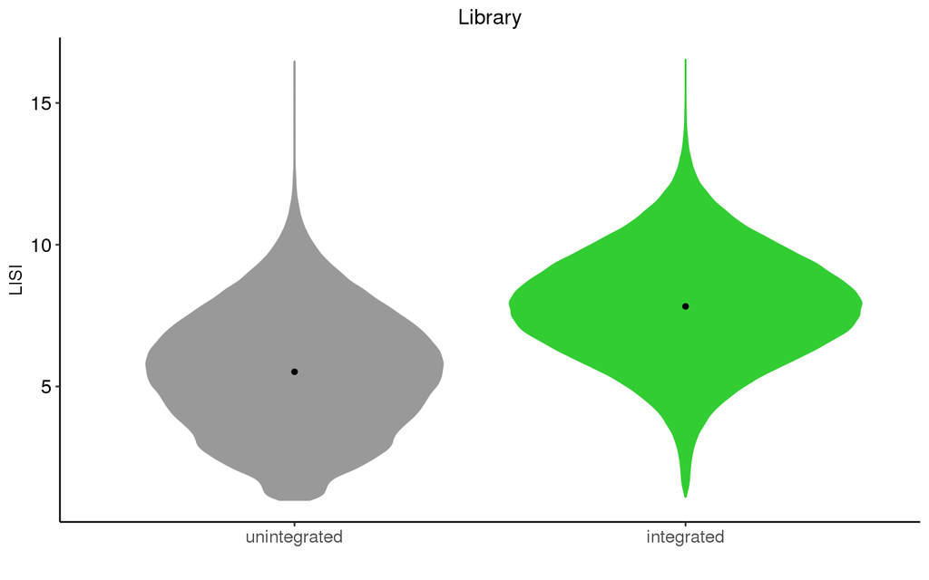

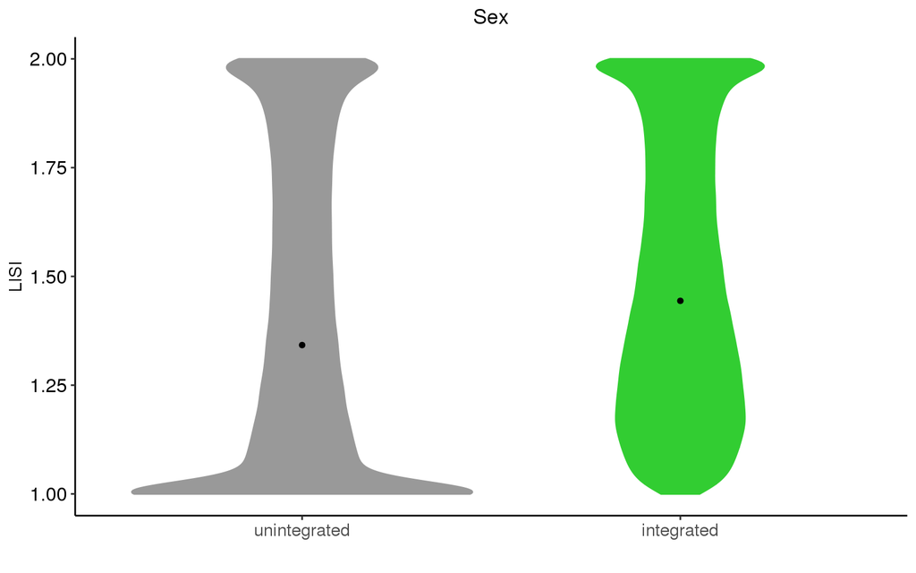

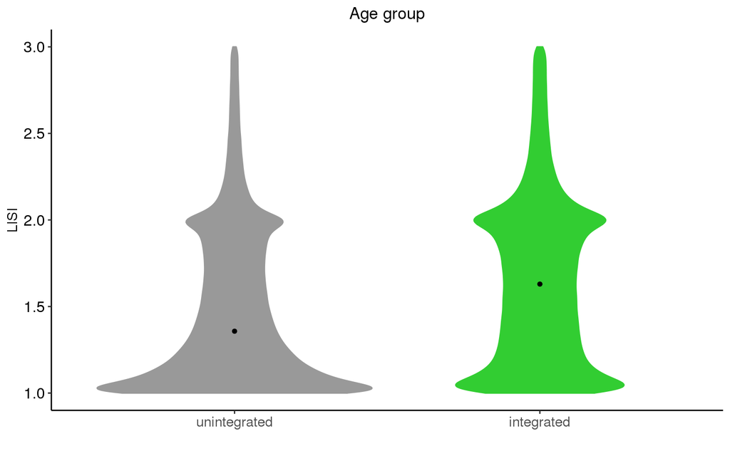

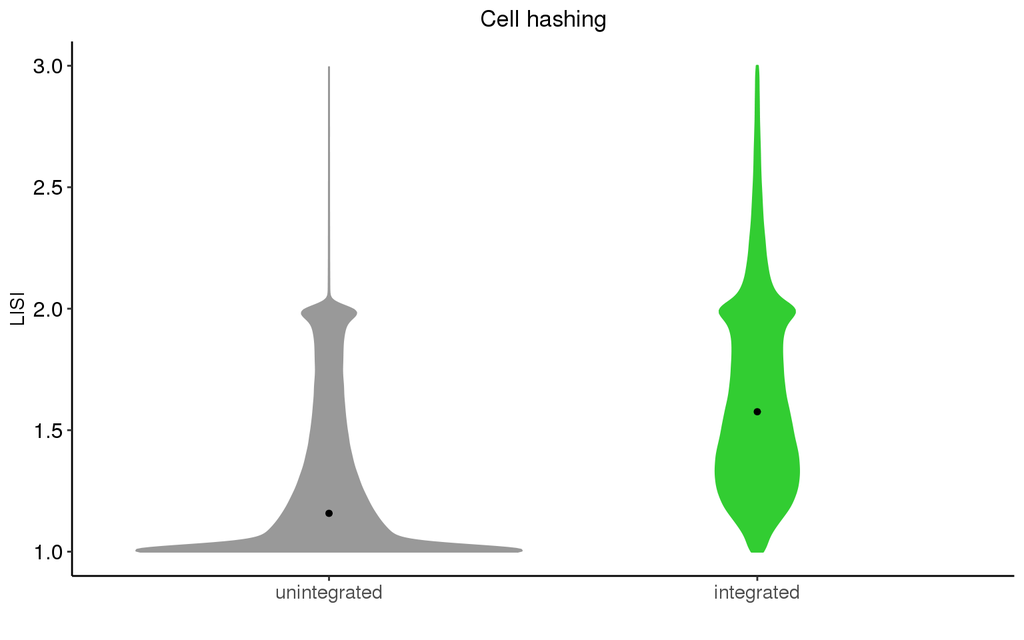

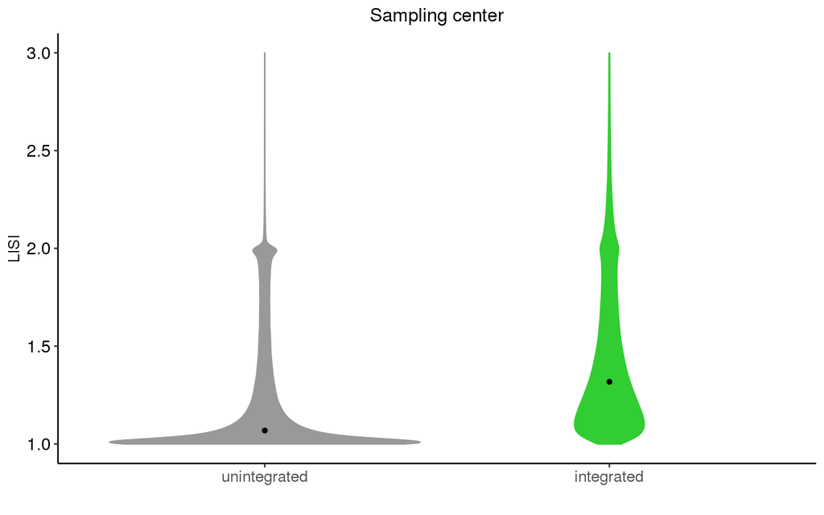

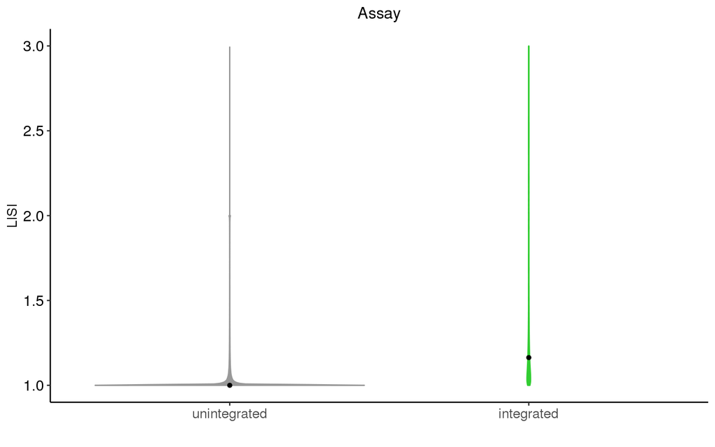

```r
confounders <- c("library_name", "sex", "age_group", "is_hashed",
                 "hospital", "assay")
plot_titles <- c("Library", "Sex", "Age group", "Cell hashing", "Sampling center", "Assay")
lisi_scores$is_integrated <- factor(lisi_scores$is_integrated, levels = c("unintegrated", "integrated"))
lisi_scores_ggs <- purrr::map2(confounders, plot_titles, function(x, title) {
  p <- lisi_scores %>%
    ggplot(aes_string(
      "is_integrated",
      x,
      color = "is_integrated",
      fill = "is_integrated"
      )
    ) +
      geom_violin() +
      stat_summary(fun = median, geom = "point", size = 1.25, color= "black") +
      scale_color_manual(values = c("gray60", "limegreen")) +
      scale_fill_manual(values = c("gray60", "limegreen")) +
      labs(title = title, x = "", y = "LISI") +
      theme_classic() +
      theme(
        legend.position = "none",
        plot.title = element_text(size = 13, hjust = 0.5),
        strip.text = element_text(color = "black", size = 12),
        axis.title.x = element_text(color = "black", size = 13),
        axis.text.y = element_text(color = "black", size = 12),
        axis.text.x = element_text(size = 11)
      )
  p
})
names(lisi_scores_ggs) <- confounders
lisi_scores_ggs
```

# 4 5’ vs 3’

As we can see above, Harmony seems to successfully correct for all confounders except for the assay. However, we hypothesize that, since we have way less cells profiled with the 5’ protocol, the LISI is biased towards the class with more cells. Thus, let us stratify the scores by assay:

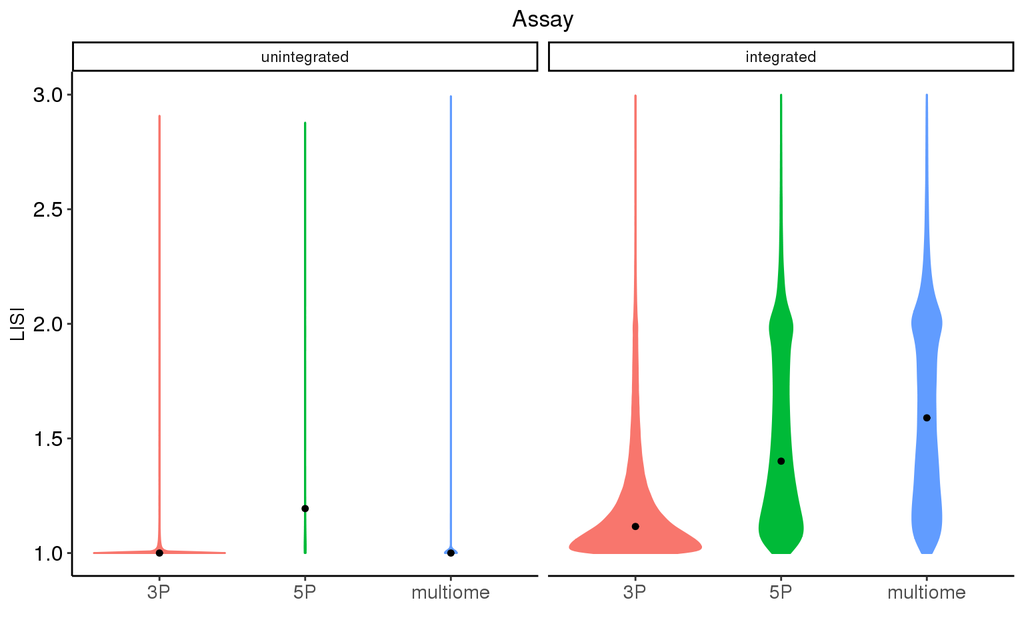

```r
assay_df <- lisi_scores[, c("is_integrated", "assay")]
colnames(assay_df) <- c("is_integrated", "lisi")
assay_gg <- assay_df %>%
  mutate(assay = c(confounders_df$assay, confounders_df$assay)) %>%
  ggplot(aes(assay, lisi, color = assay, fill = assay)) +
    geom_violin() +
    stat_summary(fun = median, geom = "point", size = 1.25, color= "black") +
    facet_wrap(. ~ is_integrated) +
    labs(title = "Assay", x = "", y = "LISI") +
    theme_classic() +
    theme(
      legend.position = "none",
      plot.title = element_text(size = 13, hjust = 0.5),
      axis.title.x = element_text(color = "black", size = 13),
      axis.text.y = element_text(color = "black", size = 12),
      axis.text.x = element_text(size = 11)
    )
assay_gg
```

Clearly, the intermixing of cells in the 5’ and multiome assays improves greatly after integration.

# 5 Save

We will save the LISI scores to plot the supplementary figures for publication:

```r
confounders_df <- confounders_df[confounders_df$hospital != "Royal London", ]
lisi_scores <- lisi_scores[str_detect(rownames(lisi_scores), "^B", negate = TRUE), ]
confounders_df$barcode <- rownames(confounders_df)
colnames(lisi_scores) <- ifelse(
  colnames(lisi_scores) == "is_integrated",
  "is_integrated",
  str_c("lisi", colnames(lisi_scores), sep = "_")
)
lisi_scores$barcode <- str_sub(rownames(lisi_scores), 1, 36)
supp_lisi_df <- left_join(x = lisi_scores, y = confounders_df, by = "barcode")
write_delim(supp_lisi_df, path_to_save_supp_df, delim = ";", col_names = TRUE)
```